# **Fibre Study: Enhancing Understanding of Dietary Fibres and Their impact on Human Health**

Did you know that most people don’t eat enough dietary fibres? This can increase the risk of chronic diseases like heart disease and colon cancer. But don’t worry! The Fibre Study is all about understanding how different types of dietary fibres are processed in our body. We want to find out how quickly different fibres reach our lower gut and what happens to them in our blood, urine and poop after we eat them.

## **Our Goal**

By studying dietary fibres, we hope to find out how long it takes the fibre to travel through our gut. We also want to identify the chemical compounds that are produced after you eat different dietary fibres. This information will help us understand the effects of dietary fibres on our bodies. It might even help shape future advice about fibres and disease risk, as well as potentially reduce healthcare costs.

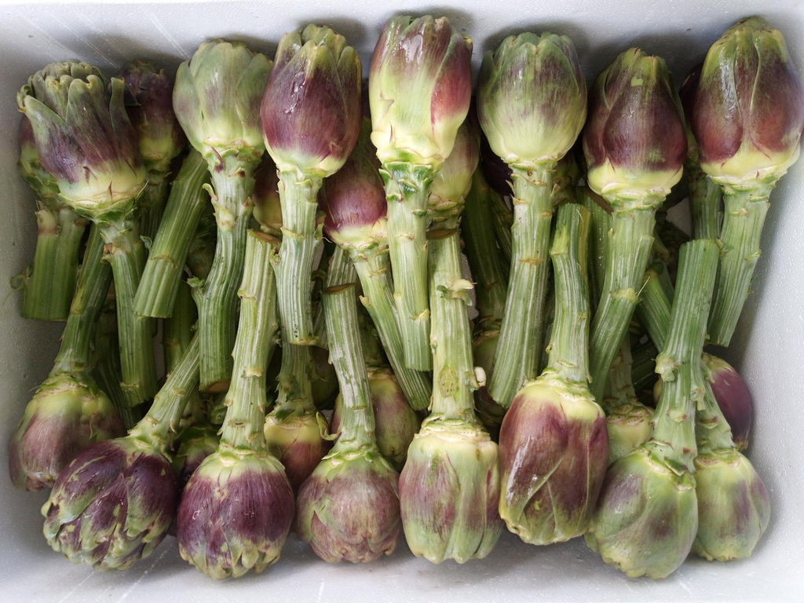

*Fresh artichokes*

## **Study design**

We will ask participants to eat one of eight different dietary fibres. You may even be involved in more than one fibre study! And guess what? We will provide all the meals during the study, so you don’t have to worry about cooking the food.

## **Study method**

We will test each dietary fibre on a group ten people. During the first visit (screening visit), we will check if you are eligible by having you consume a small amount of inulin powder dissolved in water. Twenty-four hours before the clinic visit, we will ask you to follow a low fibre diet for one day. On the day of the clinic visit, you will continue with the low fibre diet but have up to three portions of the dietary fibres for breakfast. During the screening and clinic visits, you will undergo a series of hydrogen breath tests by exhaling into a machine. On the clinic visit, we will also collect urine and blood samples to learn more about what is happening in your body. If you feel comfortable, you can even provide a poop sample!

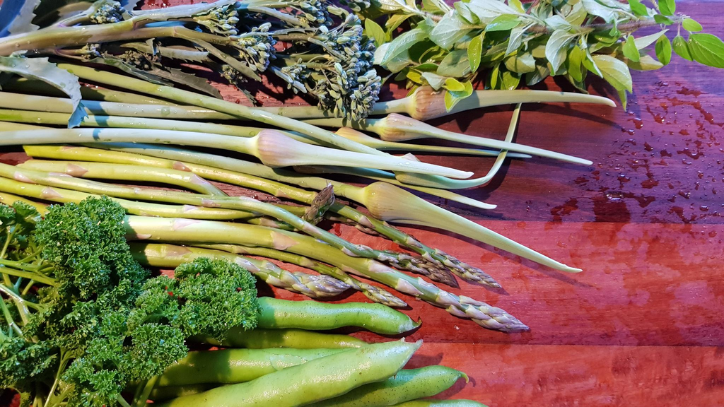

*Various fresh produces from Mt Lindesay*

## **Study status**

We are currently in the process of recruiting participants.

## **Potential benefits to participants**

As a thank you for participating, we will provide you with standardised meals for three days. You will also get to attend an educational group session where you will learn more about dietary fibres and gut health.Plus, you will have a one-on- one session with a dietician who will help you understand your metabolic health and how much dietary fibre you should consume. As a gesture of gratitude, you will receive a $25 voucher after the screening visit and a $50 voucher for the clinic visit.

## **Funding**

The study is supported by Future Food System Cooperative Research Centre (FFS CRC) and Murdoch University, in collaboration with Mt Lindesay.

## **Interested in participating?**

Find out more by reading this participant information leaflet. Or contact us, we will send you a link for electronic consent.

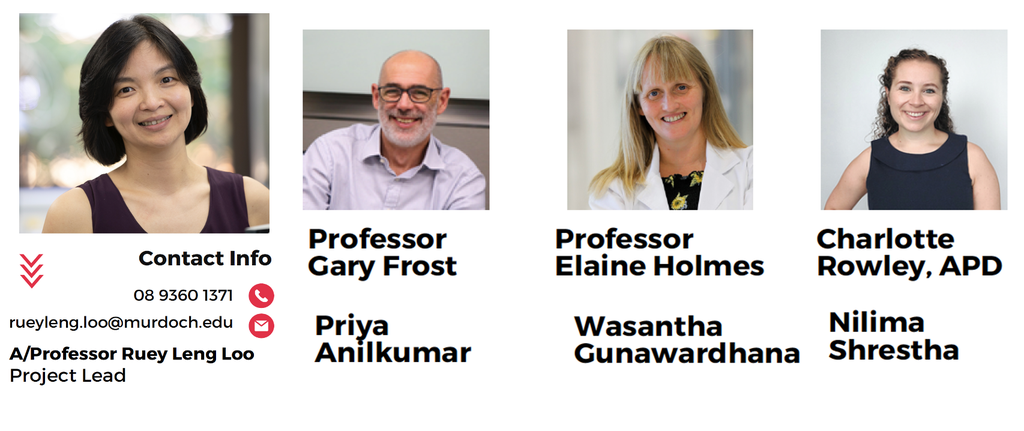

*Project Team Members*